# 本节概览

## 解决文字问题

1. from pylab import mpl

   mpl.rcParams["font.sans-serif"]=["SimHei"]

   mpl.rcParams["axes.unicode_minus"]=False

## 给图像增加标题和刻度标签等的功能

2. plt.title="图表标题名称"

   plt.x_label="x轴刻度标签"

   plt.y_label="y轴刻度标签"

## 增加网格显示

3. plt.grid(True,linestyle="自定义的样式",alpha="自己设置的不透明度，1为不透明，0为透明，0.5为半透明")

## 添加自定义刻度

4. plt.xticks(x,**kwargs)

   plt.yticks(y,**kwargs)

   注意，后面的关键字参数可以自定义为字符串样式的参数

   简单记忆，如果只要数字，那就只写一个参数就可以，但是如果刻度标识想要改成自己设置的文字字符串，那就要加上后面的关键字参数指定替换掉原来的数字刻度

## 保存图像到默认的路径为图片

5. plt.savefig("默认路径/xxx.png")

   注意，保存图像为图片的语句一定要写在显示图像之前

# 基础绘图功能，以折线图为例

### 目标

- 掌握给图形添加辅助功能(如:标注、x,y轴名称、标题等)
- 知道图形的保存
- 知道如何给plot多次绘图
- 知道如何多个坐标系显示图形
- 知道折线图的使用场景

## 完善原始折线图-给图形添加辅助功能

为了更好理解所有基础绘图功能，我们通过天气温度变化的绘图来融合所有的基础API使用

需求:画出某城市11点到12点一小时以内每分钟的气温变化折线图，温度范围在15-18度

### 基础图像

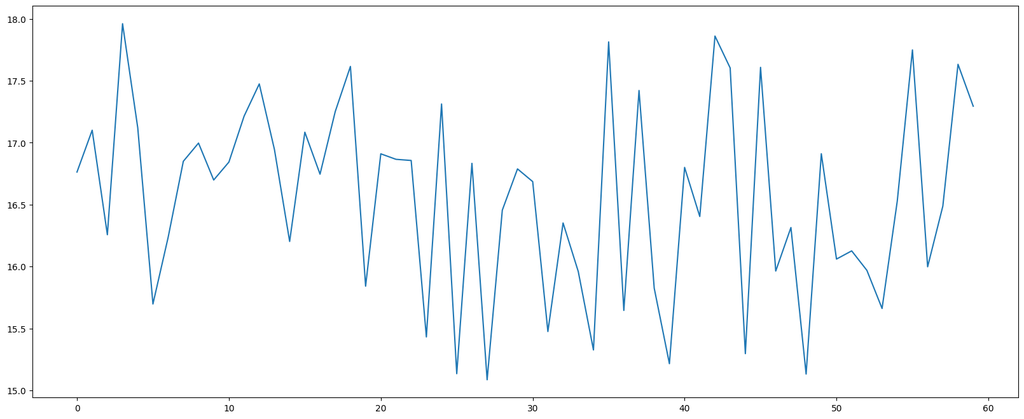

```python
# 导包
import matplotlib.pyplot as plt
import random
# 数据准备
x=range(60)
# 利用uniform(n,m)可以实现在n,m上随机生成一个实数，利用列表生成式可以实现生成60分钟内每一分钟的数据
y=[random.uniform(15,18) for i in x]
# 创建画布
plt.figure(figsize=(20,8),dpi=100)

# 绘制折线图
plt.plot(x,y)

# 显示折线图
plt.show()
```

### 实现给图像增加标题等的功能

添加自定义刻度

- plt.xticks(x,**kwargs)  
  其中x：要显示的刻度值  
  后面传入的关键字参数可以作为坐标轴的尺度
- plt.yticks(y,**kwargs)  
  其中y：要显示的刻度值

为了解决中文不显示的问题我们需要进行以下操作

1. from pylab import mpl
2. mpl.rcParams["font.sans-serif"]=["SimHei"]

注意，有时候会导致部分字符无法正常显示，那就需要更改axes.unicode_minus参数

mpl.rcParams["axes.unicode_minus"]=False

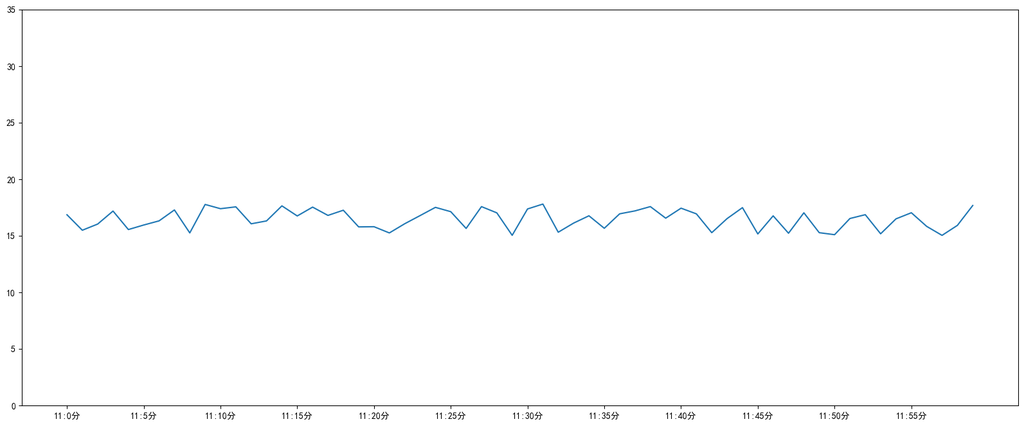

```python
# 导包
from pylab import mpl
import matplotlib.pyplot as plt
import random
# 设置显示中文字体
mpl.rcParams["font.sans-serif"] = ["SimHei"]
# 解决部分字符无法正常显示的问题
mpl.rcParams["axes.unicode_minus"]=False
# 数据准备
x=range(60)
# 利用uniform(n,m)可以实现在n,m上随机生成一个实数，利用列表生成式可以实现生成60分钟内每一分钟的数据
y=[random.uniform(15,18) for i in x]
# # 创建画布
plt.figure(figsize=(20,8),dpi=100)
#
# 绘制折线图
plt.plot(x,y)
# 添加x,y轴刻度
x_ticks_label=["11:{}分".format(i) for i in x]
# 如果跑出的图出现字体报错，那么要安装字体，这个可以长久性解决问题
# 或者在python脚本中动态设置matplotlibrc
y_ticks = range(40)

# 修改x,y刻度显示
# 利用列表的索引切分[start:stop:step],让x轴刻度为5个5个调
plt.xticks(x[::5],x_ticks_label[::5]) #坐标刻度不可以直接通过字符串修改
plt.yticks(y_ticks[::5])
# 显示折线图
plt.show()
```

网格显示是为了更清楚地观察图形对应的值

plt.grid(True,linestyle='--',alpha=0.5)

1. 其中linestyle指定的是网格线的样式
2. alpha是指定透明度用的

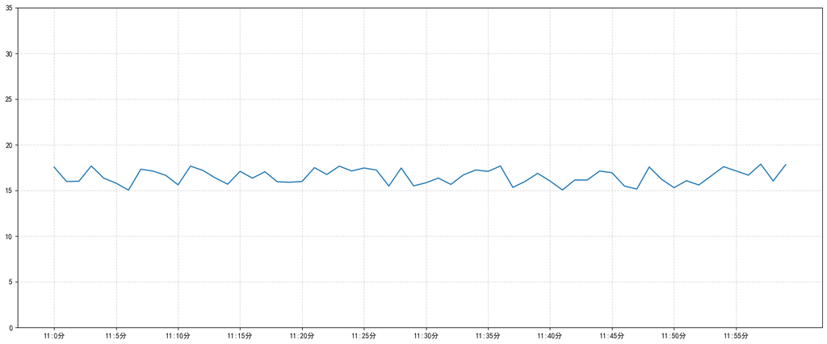

```python
# 导包
from pylab import mpl
import matplotlib.pyplot as plt
import random
# 设置显示中文字体
mpl.rcParams["font.sans-serif"] = ["SimHei"]
# 解决部分字符无法正常显示的问题
mpl.rcParams["axes.unicode_minus"]=False
# 数据准备
x=range(60)
# 利用uniform(n,m)可以实现在n,m上随机生成一个实数，利用列表生成式可以实现生成60分钟内每一分钟的数据
y=[random.uniform(15,18) for i in x]
# # 创建画布
plt.figure(figsize=(20,8),dpi=100)
# 添加网格显示
plt.grid(True,linestyle='--',alpha=0.5)
#
# 绘制折线图
plt.plot(x,y)
# 添加x,y轴刻度
x_ticks_label=["11:{}分".format(i) for i in x]
# 如果跑出的图出现字体报错，那么要安装字体，这个可以长久性解决问题
# 或者在python脚本中动态设置matplotlibrc
y_ticks = range(40)

# 修改x,y刻度显示
# 利用列表的索引切分[start:stop:step],让x轴刻度为5个5个调
plt.xticks(x[::5],x_ticks_label[::5]) #坐标刻度不可以直接通过字符串修改
plt.yticks(y_ticks[::5])
# 显示折线图
plt.show()
```

添加描述信息 添加x轴,y轴描述信息及标题

```
plt.xlabel("时间")
    plt.ylabel("温度")
    plt.title("中午11点0分到12点之间的温度变化图示",fontsize=20)
```

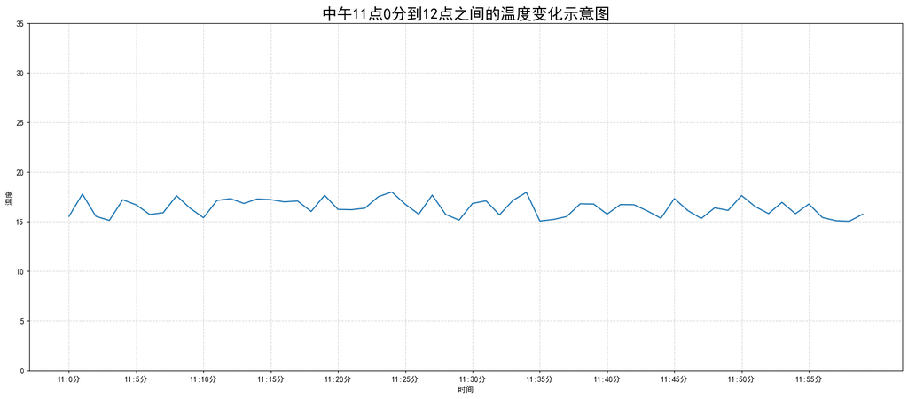

```python
# 导包
from pylab import mpl
import matplotlib.pyplot as plt
import random
# 设置显示中文字体
mpl.rcParams["font.sans-serif"] = ["SimHei"]
# 解决部分字符无法正常显示的问题
mpl.rcParams["axes.unicode_minus"]=False
# 数据准备
x=range(60)
# 利用uniform(n,m)可以实现在n,m上随机生成一个实数，利用列表生成式可以实现生成60分钟内每一分钟的数据
y=[random.uniform(15,18) for i in x]
# # 创建画布
plt.figure(figsize=(20,8),dpi=100)
# 添加网格显示
plt.grid(True,linestyle='--',alpha=0.5)
#
# 绘制折线图
plt.plot(x,y)
# 添加x轴,y轴的描述信息及标题
plt.xlabel("时间")
plt.ylabel("温度")
plt.title("中午11点0分到12点之间的温度变化示意图",fontsize=20)
# 添加x,y轴刻度
x_ticks_label=["11:{}分".format(i) for i in x]
# 如果跑出的图出现字体报错，那么要安装字体，这个可以长久性解决问题
# 或者在python脚本中动态设置matplotlibrc
y_ticks = range(40)

# 修改x,y刻度显示
# 利用列表的索引切分[start:stop:step],让x轴刻度为5个5个调
plt.xticks(x[::5],x_ticks_label[::5]) #坐标刻度不可以直接通过字符串修改
plt.yticks(y_ticks[::5])
# 显示折线图
plt.show()
```

### 图像保存

plt.savefig("指定路径")

注意，图像保存一定要写在plt.show()之前，否则会出现图像空白

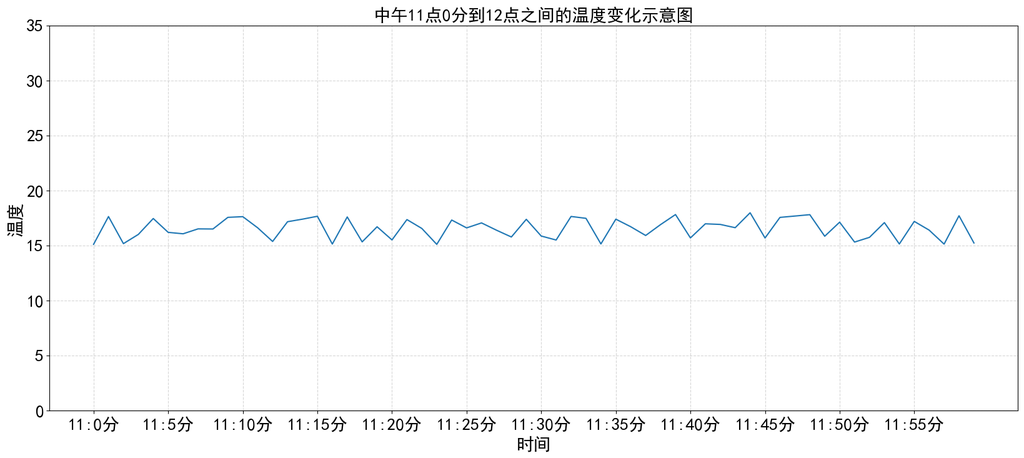

```python
# 导包
from pylab import mpl
import matplotlib.pyplot as plt
import random
# 设置显示中文字体
mpl.rcParams["font.sans-serif"] = ["SimHei"]
# 解决部分字符无法正常显示的问题
mpl.rcParams["axes.unicode_minus"]=False
# 数据准备
x=range(60)
# 利用uniform(n,m)可以实现在n,m上随机生成一个实数，利用列表生成式可以实现生成60分钟内每一分钟的数据
y=[random.uniform(15,18) for i in x]
# # 创建画布
plt.figure(figsize=(20,8),dpi=100)
# 添加网格显示
plt.grid(True,linestyle='--',alpha=0.5)
#
# 绘制折线图
plt.plot(x,y)
# 添加x轴,y轴的描述信息及标题
plt.xlabel("时间",fontsize=20)
plt.ylabel("温度",fontsize=20)
plt.title("中午11点0分到12点之间的温度变化示意图",fontsize=20)
# 添加x,y轴刻度
x_ticks_label=["11:{}分".format(i) for i in x]
# 如果跑出的图出现字体报错，那么要安装字体，这个可以长久性解决问题
# 或者在python脚本中动态设置matplotlibrc
y_ticks = range(40)

# 修改x,y刻度显示
# 利用列表的索引切分[start:stop:step],让x轴刻度为5个5个调
plt.xticks(x[::5],x_ticks_label[::5],fontsize=20) #坐标刻度不可以直接通过字符串修改
plt.yticks(y_ticks[::5],fontsize=20)
# 设置图片保存
plt.savefig("./tempraturedemo1.png")
# 显示折线图
plt.show()
```

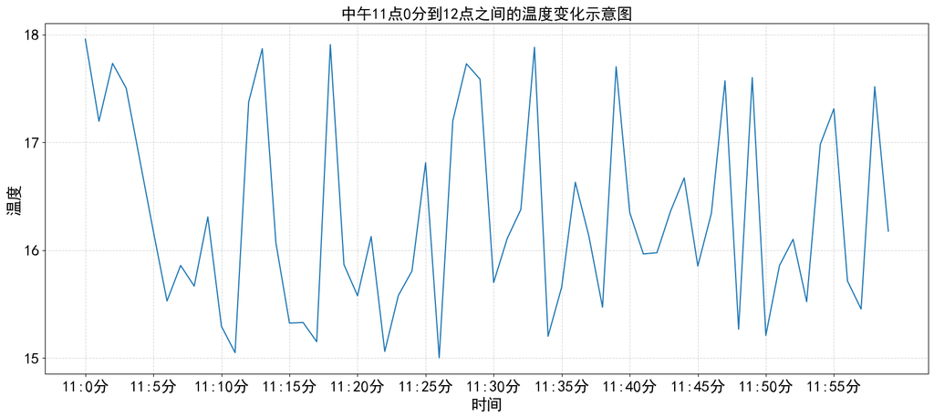

```python
# 导包
from pylab import mpl
import matplotlib.pyplot as plt
import random
# 设置显示中文字体
mpl.rcParams["font.sans-serif"] = ["SimHei"]
# 解决部分字符无法正常显示的问题
mpl.rcParams["axes.unicode_minus"]=False
# 数据准备
x=range(60)
# 利用uniform(n,m)可以实现在n,m上随机生成一个实数，利用列表生成式可以实现生成60分钟内每一分钟的数据
y_s=[random.uniform(15,18) for i in x]
# # 创建画布
plt.figure(figsize=(20,8),dpi=100)
# 添加网格显示
plt.grid(True,linestyle='--',alpha=0.5)
#
# 绘制折线图
plt.plot(x,y_s)
# 添加x轴,y轴的描述信息及标题
plt.xlabel("时间",fontsize=20)
plt.ylabel("温度",fontsize=20)
plt.title("中午11点0分到12点之间的温度变化示意图",fontsize=20)
# 添加x,y轴刻度
x_ticks_label=["11:{}分".format(i) for i in x]
# y_ticks_label=["{}℃".format(i) for i in y]
y_ticks = range(15,19)

# 修改x,y刻度显示
# 利用列表的索引切分[start:stop:step],让x轴刻度为5个5个调
plt.xticks(x[::5],x_ticks_label[::5],fontsize=20) #坐标刻度不可以直接通过字符串修改
plt.yticks(y_ticks,fontsize=20)
# plt.xticks(y,y_ticks_label,fontsize=20)

# 设置图片保存
# plt.savefig("./tempraturedemo1.png")
# 显示折线图
plt.show()
```